### اصول علم داده

### فصل دوم: پایتون برای علم داده- بخش اول

# مدرس: میلاد وزان

به تاریخ ششم اسفندماه هزار و چهارصد و یک

http://ds.miladvazan.ir/

#### فهرست مطالب

### چرا پایتون؟

### کلمات کلیدی

### شناسه

### متغیرها

### انواع داده‌ها

### عملگرها

#### چرا پایتون

پایتون یک زبان برنامه‌نویسی شی‌گرا و سطح بالا است که برای طیف گسترده‌ای از مسائل با مقیاس و پیچیدگی‌های مختلف استفاده می‌شود. برخلاف بسیاری از زبان‌های مشابه، تسلط و یادگیری آن آسان است و برای مبتدیان بسیار ایده‌آل می‌باشد. اما این آسان بودن دلیلی بر کم اهمیت بودن آن نیست و حتی برای کاربران پیشرفته نیز به اندازه کافی قدرتمند می‌باشد.

پایتون به دلیل ویژگی‌های که در زیر آن‌ها را فهرست کرده‌ایم، علم داده را به تسخیر خود در آورده است:

- **یادگیری آسان:** به لطف تمرکز پایتون بر سادگی و خوانایی، منحنی یادگیری تدریجی و نسبتاً پایینی دارد. این سهولت یادگیری، پایتون را به ابزاری ایده‌آل برای برنامه‌نویسان مبتدی تبدیل می‌کند. پایتون به برنامه‌نویسان این مزیت را ارائه می‌دهد که از خطوط کد کم‌تری برای انجام کارها نسبت در مقایسه با زبان‌های قدیمی استفاده کنند. به عبارت دیگر، شما زمان بیشتری را صرف بازی با آن کرده و زمان کم‌تری را صرف پرداختن به کد می‌کنید.
- **کتاب‌خانه‌ها و چارچوب‌ها:** به دلیل محبوبیت، پایتون صدها کتابخانه و چارچوب مختلف را دارا است که به روند توسعه شما کمک بسیار زیادی می‌کند و در زمان بسیار صرفه‌جویی می‌کنند. به عنوان یک دانشمند داده، متوجه می‌شوید که بسیاری از این کتابخانه‌ها به علم داده و یادگیری ماشین متمرکز هستند.
- **جامعه‌ی عظیم:** یکی از دلایل مشهور بودن پایتون وجود یک جامعه‌ی عظیم متشکل از مهندسان و دانشمندان داده است. ممکن است فکر کنید که این نباید یکی از دلایل اصلی انتخاب شما برای پایتون باشد، اما حقیقت برعکس است. اگر از نظرات و پشتیبانی‌های متخصصان دیگر استفاده نکنید، مسیر یادگیری شما دشوار خواهد بود.

#### کلمات کلیدی

کلمات کلیدی برخی از کلمات رزرو شده و محفوظ در پایتون هستند که معانی خاصی دارند. از کلمات کلیدی برای تعریف دستور نحو و ساختار زبان استفاده می‌شود. کلمه کلیدی را نمی‌توان به عنوان شناسه، تابع و نام متغیر استفاده کرد. کلمات کلیدی در پایتون به حروف کوچک و بزرگ حساس هستند، بنابراین باید آن‌ها را همان‌طور که هستند، نوشت. همه کلمات کلیدی در پایتون به جز True، False و None با حروف کوچک نوشته می‌شوند. کلمات کلیدی ممکن است در نسخه‌های مختلف پایتون تغییر کند. برخی از موارد اضافی ممکن است اضافه یا برخی حذف شوند. همیشه می‌توانید لیست کلمات کلیدی نسخه فعلی خود را با تایپ کردن دستورات زیر دریافت کنید:

```python
import keyword
keyword.kwlist
```

```
['False',
 'None',
 'True',
 '__peg_parser__',
 'and',
 'as',
 'assert',
 'async',
 'await',
 'break',
 'class',
 'continue',
 'def',
 'del',
 'elif',
 'else',
 'except',
 'finally',
 'for',
 'from',
 'global',
 'if',
 'import',
 'in',
 'is',
 'lambda',
 'nonlocal',
 'not',
 'or',
 'pass',
 'raise',
 'return',
 'try',
 'while',
 'with',
 'yield']
```

#### **شمارش تعداد کلمات کلیدی:**

```python
len(keyword.kwlist)
```

```
36
```

```python
!python --version
```

```
Python 3.9.9
```

#### شناسه

شناسه نامی است که ما برای شناسایی یک متغیر، تابع، کلاس، ماژول یا شی می‌گذاریم. این امر به تمایز یک موجودیت از دیگری کمک می‌کند.

#### قوانین نوشتن شناسه

- **شناسه‌ها می‌توانند ترکیبی از حروف کوچک (a تا z) یا بزرگ (A تا Z) یا ارقام (0 تا 9) یا یک زیرین‌خط (_) باشند. نام‌هایی مانند myPython، my_Python و var_1 همگی معتبر هستند.**
- **شناسه نمی‌تواند با رقم شروع شود.**
- ** از نمادهای خاصی همانند !، @، #، $، % به‌عنوان شناسه نمی‌توان استفاده کرد. **
- **شناسه می‌تواند هر طولی داشته باشد.**
- **از فاصله نمی‌توان در نام شناسه‌ها استفاده کرد**
- **زبان پایتون نسبت به حروف کوچک و بزرگ حساس است**

چند نمونه تعریف شناسه غیرمجاز:

```python
2var = 56
```

```
  File "C:\Users\milad\AppData\Local\Temp\ipykernel_113676\3666156162.py", line 1
    2var = 56
     ^
SyntaxError: invalid syntax
```

```python
$money = 2561
```

```
  File "C:\Users\milad\AppData\Local\Temp\ipykernel_113676\3161207344.py", line 1
    $money = 2561
    ^
SyntaxError: invalid syntax
```

```python
My var = 8
```

```
  File "C:\Users\milad\AppData\Local\Temp\ipykernel_113676\2355919498.py", line 1
    My var = 8
       ^
SyntaxError: invalid syntax
```

```python
My@var = 54
```

```
  File "C:\Users\milad\AppData\Local\Temp\ipykernel_113676\1275635690.py", line 1
    My@var = 54
    ^
SyntaxError: cannot assign to operator
```

```python
My!var = 58
```

```
  File "C:\Users\milad\AppData\Local\Temp\ipykernel_113676\1696532503.py", line 1
    My!var = 58
      ^
SyntaxError: invalid syntax
```

```python
My?var = 58
```

```
  File "C:\Users\milad\AppData\Local\Temp\ipykernel_113676\2516349648.py", line 1
    My?var = 58
      ^
SyntaxError: invalid syntax
```

```python
import = 15
```

```
  File "C:\Users\milad\AppData\Local\Temp\ipykernel_113676\1523792655.py", line 1
    import = 15
           ^
SyntaxError: invalid syntax
```

چند نمونه تعریف شناسه مجاز:

```python
var = 25
```

```python
var2 = 23
```

```python
var_2 = 29
```

```python
My_Var_3 = 54
```

#### متغیر‌ها

متغیر مکان نام‌گذاری شده‌ای است که برای ذخیره داده‌ها در حافظه استفاده می‌شود. این بدان معناست که هنگام ایجاد یک متغیر، مقداری از فضا را در حافظه اشغال می‌کنید. به هر متغیر یک نام اختصاص داده می‌شود تا بتوان آن را از دیگر متغیر‌ها شناسایی و به آن‌ دسترسی پیدا کرد.

برای استفاده از متغیرها باید دو کار را انجام داد:

- **نام‌گذاری متغیر:** برای نام‌گذاری از قوانین مرتبط با شناسه‌ها استفاده می‌کنیم.
- **مقداردهی متغیر:** تخصیص مقدار به متغیرها در پایتون به این صورت است که باید نام متغیر را در سمت چپ = و مقدار متغیر را در سمت راست آن بنویسید:

```python
a = 25
b = 34
c = 4.5
st = "python"
```

لازم نیست نوع متغیر را ذکر کنید، پایتون نوع را بر اساس مقداری که ما اختصاص می‌دهیم آن را استنباط می‌کند.

برای مشاهده‌ی نوع داده‌ی متغیر از دستور ()type استفاده می‌کنیم

```python
type(a)
```

```
int
```

```python
type(c)
```

```
float
```

```python
type(st)
```

```
str
```

#### تخصیص چندگانه

پایتون به ما این امکان را می‌دهد که یک مقدار را به چند متغیر در یک دستور اختصاص دهیم که به آن تخصیص چندگانه گفته می‌شود. ما می‌توانیم تخصیص چندگانه را به دو صورت اعمال کنیم، یا با اختصاص یک مقدار واحد به چند متغیر یا اختصاص چند مقدار به چند متغیر.

اختصاص یک مقدار واحد به چند متغیر:

```python
x = y = z = 98
```

```python
x
```

```
98
```

```python
y
```

```
98
```

```python
z
```

```
98
```

اختصاص چند مقدار به چند متغیر:

```python
var_1, var_2, var_3 = 1.86, "python", 3
```

```python
var_1
```

```
1.86
```

```python
var_2
```

```
'python'
```

```python
var_3
```

```
3
```

#### انواع داده‌ها

عددی

در پایتون، نوع داده‌های عددی به داده‌هایی اشاره دارد که دارای ارزش عددی هستند. مقدار عددی می تواند صحیح، عدد ممیز شناور و یا حتی اعداد مختلط باشد. این مقادیر به عنوان کلاس int ، float و complex در پایتون تعریف می‌شوند.

```python
x = 45
y = 24.875
z = 4 + 3j
```

```python
type(x), type(y), type(z)
```

```
(int, float, complex)
```

رشته‌ها

در پایتون، رشته‌ها آرایه‌هایی از بایت‌ها هستند که کاراکترهای یونیکد را نشان می‌دهند. یک رشته مجموعه‌ای از یک یا چند کاراکتر است که در داخل '' و یا داخل یک "" قرار می‌گیرد.

```python
Str_1 = 'Python Data Types'
Str_1
```

```
'Python Data Types'
```

```python
Str_2 = "python vs Julia"
Str_2
```

```
'python vs Julia'
```

```python
type(Str_1), type(Str_2)
```

```
(str, str)
```

*در پایتون هیچ نوع داده کاراکتری وجود ندارد، یک کاراکتر یک رشته با طول یک است.

```python
C = 'M'
type(C)
```

```
str
```

```python
type('N')
```

```
str
```

تبدیل نوع

مشابه با سایر زبان‌ها در زبان پایتون می‌توان یک شی داده‌ای را به شی داده‌ای دیگر تبدیل کرد. برای این کار توابعی وجود دارد که در ادامه آن‌ها را معرفی می‌کنیم

تابع ()int

به وسیله‌ی آن می‌توان هر نوع داده‌ای را به داده‌ی از نوع عدد صحیح تبدیل کرد.

```python
int(56.32)
```

```
56
```

```python
x = 15.5
```

```python
int(x)
```

```
15
```

```python
st = "2546"
```

```python
int(st)
```

```
2546
```

*توجه

```python
st2 = "python"
```

```python
int(st2)
```

```
---------------------------------------------------------------------------
ValueError                                Traceback (most recent call last)
~\AppData\Local\Temp\ipykernel_113676\2869572574.py in <cell line: 1>()
----> 1 int(st2)

ValueError: invalid literal for int() with base 10: 'python'
```

تابع ()float

برای تبدیل به اعشاری (ممیزشناور)

```python
float(6)
```

```
6.0
```

```python
x = 3
```

```python
float(x)
```

```
3.0
```

```python
float("245")
```

```
245.0
```

#### عملگرها

از عملگرهای پایتون به‌طور کلی برای انجام عملیات برروی مقادیر و متغیرها استفاده می‌شود. آن‌ها نمادهای استانداردی هستند که به‌منظور انجام عملیات منطقی، حسابی و مقایسه‌ای مورد استفاده قرار می‌گیرند.

عملگرهای حسابی

عملگرهای حسابی برای انجام عملیات ریاضی همانند جمع، تفریق، ضرب و تقسیم استفاده می‌شوند.

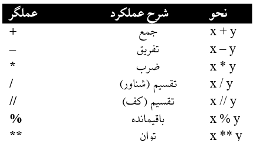

```python
x = 13
y = 2
```

```python
add = x+y
sub = x - y
mul = x * y
div1 = x / y
div2 = x // y
mod = x % y
p = x ** y
```

```python
add
```

```
15
```

```python
sub
```

```
11
```

```python
mul
```

```
26
```

```python
div1
```

```
6.5
```

```python
div2
```

```
6
```

```python
mod
```

```
1
```

```python
p
```

```
169
```

```python
add, sub, mul , div1 , div2, mod , p
```

```
(15, 11, 26, 6.5, 6, 1, 169)
```

عبارات (statement)

دستورالعمل‌هایی که مفسر پایتون می‌تواند اجرا کند.

عبارت تک خطی

```python
S1 = 20 + 2 + 1 + 7 + 4 + 8 + 6 + 6 + 1
S1
```

```
55
```

عبارت چند خطی

```python
S2 = 20 + 2 + 1+\
    7 + 4 + 8+\
    6 + 6 + 1
S2
```

```
55
```

عملگرهای منطقی

عملگرهای منطقی (and، or و not) برروی عبارات منطقی اعمال می‌شوند و نتیجه آن‌ها True و یا False است. از این عملگر‌ها برای شرط‌های پیچیده استفاده می‌شود.

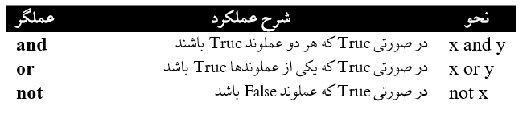

```python
X = True
Y = False
```

```python
X and Y
```

```
False
```

```python
X or Y
```

```
True
```

```python
not X
```

```
False
```

عملگرهای مقایسه‌ای

این عملگرها مقادیر دو طرف خود را مقایسه کرده و رابطه بین آن‌ها را تعیین می‌کنند. عملگرهای مقایسه‌ای را عملگرهای رابطه‌ای نیز می‌نامند.

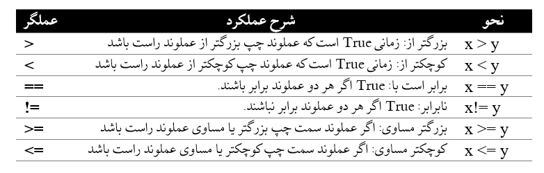

```python
a = 25
b = 12
```

```python
a > b
```

```
True
```

```python
a < b
```

```
False
```

```python
a == b
```

```
False
```

```python
a != b
```

```
True
```

```python
a >= b
```

```
True
```

```python
a <= b
```

```
False
```

عملگرهای ترکیبی

x= x+y

روش استفاده: x += y

```python
x = 4
i = 1
x += i
x
```

```
5
```

x= x-y

روش استفاده: x -= y

```python
x = 4
i = 1
x -= i
x
```

```
3
```

x= x*y

روش استفاده: x *= y

```python
x = 4
i = 2
x *= i
x
```

```
8
```

x= x/y

روش استفاده: x /= y

```python
x = 4
i = 2
x /= i
x
```

```
2.0
```

x= x%y

روش استفاده: x %= y

```python
x = 4
i = 2
x %= i
x
```

```
0
```

x= x//y

روش استفاده: x //= y

```python
x = 4.6587955
i = 2
x //= i
x
```

```
2.0
```